# Assignment 2: Spatial Analysis and Visualization

## Part 3: Bring Your Own Data Analysis

### Analysis

**Your Task:**

1. **Find and load additional data**

```r
library(sf)
library(dplyr)
# Load your additional dataset
housing_raw <- st_read("Affordable_Housing/Affordable_Housing.shp", quiet = TRUE)
n_features <- nrow(housing_raw)
crs_info <- st_crs(housing_raw)
cat("Number of features:", n_features, "\n")
```

```
Number of features: 443
```

```r
cat("Original CRS:", crs_info$input, "\n")
```

```
Original CRS: WGS 84 / Pseudo-Mercator
```

```r
#Transform CRS to match project CRS (UTM 18N; EPSG:26918)  -
analysis_crs <- 26918
housing <- st_transform(housing_raw, analysis_crs)
cat("Transformed CRS:", st_crs(housing)$input, "\n")
```

```
Transformed CRS: EPSG:26918
```

```r
#Basic summary statistics  -
summary(select(st_drop_geometry(housing), contains("YEAR"), contains("STATUS"), contains("ADDRESS")))
```

```
   ADDRESS
 Length:443
 Class :character
 Mode  :character
```

**Questions to answer:** - What dataset did you choose and why? I selected the Affordable Housing Production dataset because it aligns closely with the healthcare‐equity theme of Assignment 2. It allows me to analyze whether affordable housing projects are spatially located near essential public facilities such as hospitals or transit, providing insight into urban equity and accessibility. - What is the data source and date? The dataset comes from OpenDataPhilly, maintained by the Philadelphia Division of Housing and Community Development (DHCD).It contains projects completed since 1994 and was last updated in 2024. - How many features does it contain? 443 - What CRS is it in? Did you need to transform it? WGS 84 / Pseudo-Mercator ,EPSG:26918

2. **Pose a research question**

Write a clear research statement that your analysis will answer.

Research Question: “Are Philadelphia’s affordable housing developments equitably located relative to hospital access?” Rationale: Access to healthcare is a critical component of urban livability, particularly for residents of affordable housing. By examining the spatial relationship between affordable housing projects and hospital service areas, this analysis aims to evaluate whether low-income populations have adequate proximity to essential healthcare facilities. Policy Relevance: Findings can inform city planning and equitable investment strategies for both housing andhealthcare infrastructure, highlighting neighborhoods where affordable housing expansion should be paired with improved health service accessibility.

3. **Conduct spatial analysis**

**Your Task:**

```r
# Your spatial analysis
# --- Spatial Analysis: Affordable Housing vs. Hospital Access (EPSG:26918) ---

# Load required packages

suppressPackageStartupMessages({
library(sf)
library(dplyr)
library(units)
library(ggplot2)
library(tigris)
library(osmdata)
library(janitor)
})

# Configure tigris options

options(tigris_use_cache = TRUE, tigris_class = "sf")

# Set coordinate reference system (UTM 18N)

analysis_crs <- 26918

# Load study area boundary (Philadelphia)

philly <- places(state = "PA", cb = TRUE, year = 2023) |>
filter(NAME == "Philadelphia") |>
st_transform(analysis_crs)

# Load hospital data: use local shapefile if available; otherwise download from OSM

if (file.exists("DOH_Hospitals202311/DOH_Hospitals202311.shp")) {
hospitals_pts <- st_read("DOH_Hospitals202311/DOH_Hospitals202311.shp", quiet = TRUE) |>
st_transform(analysis_crs) |>
st_intersection(philly)
hosp_source <- "Local shapefile (data/Hospitals.shp)"
} else {

# Otherwise download from OpenStreetMap

bbox_wgs84 <- st_transform(philly, 4326) |> st_bbox()
q <- opq(bbox = bbox_wgs84) |>
add_osm_feature(key = "amenity", value = "hospital")

osm <- osmdata_sf(q)
hosp_pts_osm <- osm$osm_points
hosp_poly_osm <- osm$osm_polygons

# Convert hospital polygons to centroids

hosp_poly_centroids <- NULL
if (!is.null(hosp_poly_osm) && nrow(hosp_poly_osm) > 0) {
hosp_poly_centroids <- st_centroid(st_geometry(hosp_poly_osm)) |>
st_as_sf() |>
mutate(osm_id = hosp_poly_osm$osm_id)
}

# Merge points and centroids

hospitals_pts <- bind_rows(
(hosp_pts_osm %||% st_sf())[c("osm_id", "geometry")],
(hosp_poly_centroids %||% st_sf())[c("osm_id", "geometry")]
) |>
distinct(osm_id, .keep_all = TRUE) |>
st_transform(analysis_crs) |>
st_intersection(philly)

hosp_source <- "OpenStreetMap (amenity=hospital)"
}

# Check hospital data

n_hospitals <- nrow(hospitals_pts)
cat("Hospital source:", hosp_source, "\n")
```

```
Hospital source: Local shapefile (data/Hospitals.shp)
```

```r
cat("Hospitals (n):", n_hospitals, "\n")
```

```
Hospitals (n): 26
```

```r
# Calculate distance to the nearest hospital for each housing site

stopifnot(exists("housing"))
dist_mat <- st_distance(housing, hospitals_pts)
housing$dist_hosp_m <- apply(dist_mat, 1, function(x) min(as.numeric(set_units(x, "m"))))

cat("\nDistance to nearest hospital (m):\n")
```

```
Distance to nearest hospital (m):
```

```r
print(summary(housing$dist_hosp_m))
```

```
   Min. 1st Qu.  Median    Mean 3rd Qu.    Max.    NA's
  53.74  855.89 1312.20 1533.62 2024.58 6322.51      25
```

```r
cat("Share within 1 mile (~1609 m):",
round(mean(housing$dist_hosp_m <= 1609, na.rm = TRUE) * 100, 1), "%\n")
```

```
Share within 1 mile (~1609 m): 63.9 %
```

```r
# Create 1-mile hospital service buffer

service_radius_m <- 1609
hosp_service <- st_buffer(hospitals_pts, dist = service_radius_m) |>
st_union() |>
st_as_sf() |>
st_intersection(philly)

# Flag whether each housing project is within service area

housing$served_1mi <- as.logical(st_intersects(housing, hosp_service, sparse = FALSE))
housing$served_1mi[is.na(housing$served_1mi)] <- FALSE
cat("\nAffordable housing within 1 mile of a hospital:\n")
```

```
Affordable housing within 1 mile of a hospital:
```

```r
print(tabyl(housing$served_1mi) |> adorn_pct_formatting(digits = 1))
```

```
 housing$served_1mi   n percent
              FALSE 176   39.7%
               TRUE 267   60.3%
```

```r
# Aggregate by census tracts

tracts_phl <- tracts(state = "PA", county = "Philadelphia", cb = TRUE, year = 2022) |>
st_transform(analysis_crs) |>
select(GEOID, NAME)

# Spatial join housing with tract polygons

housing_tract <- st_join(housing, tracts_phl, join = st_within, left = TRUE)

# Summarize housing accessibility per tract

tract_summary <- housing_tract |>
st_drop_geometry() |>
group_by(GEOID, NAME) |>
summarize(
n_projects = n(),
n_served = sum(served_1mi, na.rm = TRUE),
n_underserved = sum(!served_1mi, na.rm = TRUE),
pct_served = ifelse(n_projects > 0, n_served / n_projects, NA_real_),
.groups = "drop"
)

# Join tract-level summary for mapping

tracts_map <- tracts_phl |>
left_join(tract_summary, by = c("GEOID", "NAME"))

cat("\nTop 10 tracts by number of underserved projects:\n")
```

```
Top 10 tracts by number of underserved projects:
```

```r
print(tract_summary |> arrange(desc(n_underserved)) |> head(10))
```

```
# A tibble: 10 × 6
   GEOID       NAME   n_projects n_served n_underserved pct_served
   <chr>       <chr>       <int>    <int>         <int>      <dbl>
 1 <NA>        <NA>           25        0            25      0
 2 42101011000 110             8        0             8      0
 3 42101015101 151.01          7        0             7      0
 4 42101015200 152             7        0             7      0
 5 42101015300 153             5        0             5      0
 6 42101009300 93              4        0             4      0
 7 42101011900 119             4        0             4      0
 8 42101014900 149             4        0             4      0
 9 42101023700 237             4        0             4      0
10 42101003300 33              7        4             3      0.571
```

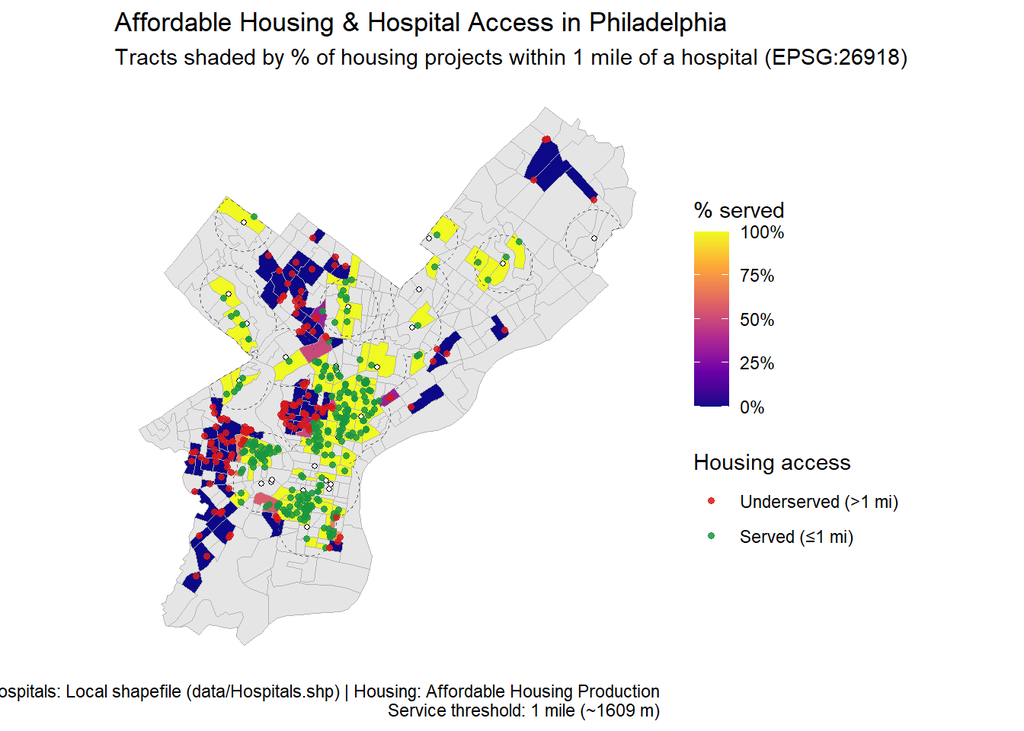

```r
# Create visualization map

p_map <- ggplot() +
geom_sf(data = tracts_map, aes(fill = pct_served), linewidth = 0.15, color = "grey70") +
scale_fill_viridis_c(
option = "plasma", na.value = "grey90",
name = "% served",
labels = scales::percent_format(accuracy = 1),
limits = c(0, 1)
) +
geom_sf(data = hosp_service, fill = NA, linewidth = 0.3, linetype = "dashed") +
geom_sf(data = hospitals_pts, size = 1.2, shape = 21, fill = "white", stroke = 0.3) +
geom_sf(
data = housing,
aes(color = served_1mi),
size = 1.3, alpha = 0.85
) +
scale_color_manual(
values = c("FALSE" = "#d7191c", "TRUE" = "#1a9641"),
labels = c("Underserved (>1 mi)", "Served (≤1 mi)"),
name = "Housing access"
) +
coord_sf(datum = NA) +
labs(
title = "Affordable Housing & Hospital Access in Philadelphia",
subtitle = "Tracts shaded by % of housing projects within 1 mile of a hospital (EPSG:26918)",
caption = paste0("Hospitals: ", hosp_source, " | Housing: Affordable Housing Production\n",
"Service threshold: 1 mile (~1609 m)"),
x = NULL, y = NULL
) +
theme_minimal(base_size = 11) +
theme(
legend.position = "right",
panel.grid.major = element_line(linewidth = 0.1, color = "grey90")
)

p_map
```

```r
# Summary statistics

n_total <- nrow(housing)
n_served <- sum(housing$served_1mi, na.rm = TRUE)
n_underserved <- sum(!housing$served_1mi, na.rm = TRUE)
median_dist <- median(housing$dist_hosp_m, na.rm = TRUE)

cat("\n=== Key Results ===\n")
```

```
=== Key Results ===
```

```r
cat("Total housing projects:", n_total, "\n")
```

```
Total housing projects: 443
```

```r
cat("Served (<=1 mile):", n_served, sprintf("(%.1f%%)", 100*n_served/n_total), "\n")
```

```
Served (<=1 mile): 267 (60.3%)
```

```r
cat("Underserved (>1 mile):", n_underserved, sprintf("(%.1f%%)", 100*n_underserved/n_total), "\n")
```

```
Underserved (>1 mile): 176 (39.7%)
```

```r
cat("Median distance to nearest hospital:", round(median_dist), "m\n")
```

```
Median distance to nearest hospital: 1312 m
```

**interpretation:**

Analysis shows that 60.3% of Philadelphia’s affordable housing projects are located within one mile of a hospital, while 39.7% of the projects remain underserved. The median distance to the nearest hospital is approximately 1.3 kilometers (1,312 meters), indicating that overall spatial accessibility is moderate but unevenly distributed. Underserved areas are concentrated in the northern and southwestern parts of the city, where clusters of affordable housing are located far from major medical institutions. In contrast, the central and southern parts of Philadelphia have higher accessibility due to the dense concentration of hospitals. These findings suggest that future housing investments should prioritize underserved areas to improve healthcare equity across the city.

## Finally - A few comments about your incorporation of feedback!

1.Added brief explanations for outputs. 2.Personal reference text is not displayed in Markdown. 3.Hid the setup code block. 4.Removed the [brackets] from the text.